# you got the heart sick?

# 5 Tuning Cutoff

Known for max threshold from what we are seeing

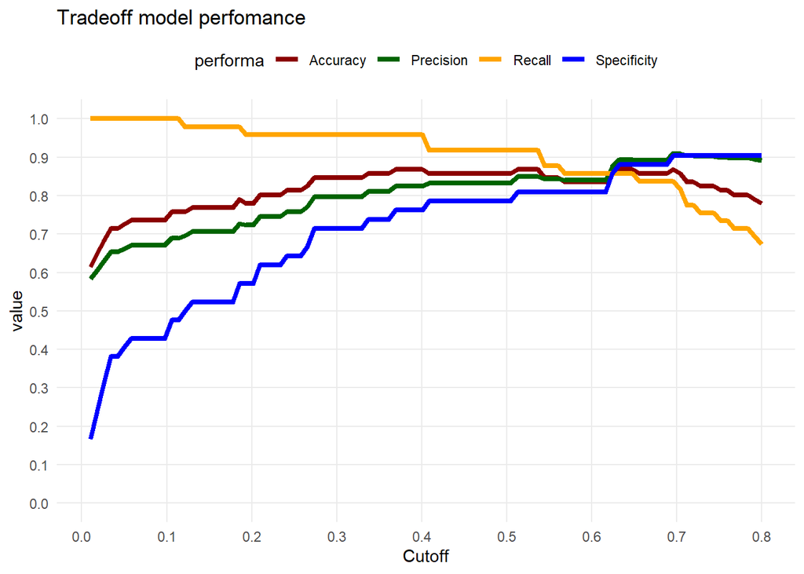

```r
# tuning cutoff
performa <- function(cutoff, prob, ref, postarget, negtarget)
{
  predict <- factor(ifelse(prob >= cutoff, postarget, negtarget))
  conf <- caret::confusionMatrix(predict , ref, positive = postarget)
  acc <- conf$overall[1]
  rec <- conf$byClass[1]
  prec <- conf$byClass[3]
  spec <- conf$byClass[2]
  mat <- t(as.matrix(c(rec , acc , prec, spec)))
  colnames(mat) <- c("recall", "accuracy", "precicion", "specificity")
  return(mat)
}

co <- seq(0.01,0.80,length=100)
result <- matrix(0,100,4)

for(i in 1:100){
  result[i,] = performa(cutoff = co[i],
                     prob = heart_test$prob_heart,
                     ref = heart_test$target,
                     postarget = "Not Health",
                     negtarget = "Health")
}

data_frame("Recall" = result[,1],
           "Accuracy" = result[,2],
           "Precision" = result[,3],
           "Specificity" = result[,4],
                   "Cutoff" = co) %>%
  gather(key = "performa", value = "value", 1:4) %>%
  ggplot(aes(x = Cutoff, y = value, col = performa)) +
  geom_line(lwd = 1.5) +
  scale_color_manual(values = c("darkred","darkgreen","orange", "blue")) +
  scale_y_continuous(breaks = seq(0,1,0.1), limits = c(0,1)) +
  scale_x_continuous(breaks = seq(0,1,0.1)) +
  labs(title = "Tradeoff model perfomance") +
  theme_minimal() +
  theme(legend.position = "top",
        panel.grid.minor.y = element_blank(),
        panel.grid.minor.x = element_blank())
```

# 6 Model Interpretation

```r
# Odds ratio all coefficients
exp(model2$coefficients) %>%
  data.frame()
```

|  | . |
| --- | --- |
| (Intercept) | 9.653188e-01 |
| sexMale | 3.977241e-01 |
| cp1 | 1.676569e+00 |
| cp2 | 7.621062e+00 |
| cp3 | 6.714734e+00 |
| exangYes | 2.962824e-01 |
| oldpeak | 6.768212e-01 |
| slope1 | 5.323100e-01 |
| slope2 | 3.316779e+00 |
| ca1 | 1.522204e-01 |

[output cut: 6 more lines]

# 7 K-Nearest Neighbor

## 7.1 Pre Processing Data

Make a dummy variable from category datas that we are using in the classification

```r
dmy <- dummyVars(" ~target+sex+cp+fbs+exang+oldpeak+slope+ca+thal", data = heart)
dmy <- data.frame(predict(dmy, newdata = heart))
str(dmy)
```

```
## 'data.frame':    303 obs. of  25 variables:
##  $ target.Health    : num  0 0 0 0 0 0 0 0 0 0 ...
##  $ target.Not.Health: num  1 1 1 1 1 1 1 1 1 1 ...
##  $ sex.Female       : num  0 0 1 0 1 0 1 0 0 0 ...
##  $ sex.Male         : num  1 1 0 1 0 1 0 1 1 1 ...
##  $ cp.0             : num  0 0 0 0 1 1 0 0 0 0 ...
##  $ cp.1             : num  0 0 1 1 0 0 1 1 0 0 ...
##  $ cp.2             : num  0 1 0 0 0 0 0 0 1 1 ...
##  $ cp.3             : num  1 0 0 0 0 0 0 0 0 0 ...
##  $ fbs.False        : num  0 1 1 1 1 1 1 1 0 1 ...
##  $ fbs.True         : num  1 0 0 0 0 0 0 0 1 0 ...
##  $ exang.No         : num  1 1 1 1 0 1 1 1 1 1 ...
##  $ exang.Yes        : num  0 0 0 0 1 0 0 0 0 0 ...
##  $ oldpeak          : num  2.3 3.5 1.4 0.8 0.6 0.4 1.3 0 0.5 1.6 ...
##  $ slope.0          : num  1 1 0 0 0 0 0 0 0 0 ...
##  $ slope.1          : num  0 0 0 0 0 1 1 0 0 0 ...
##  $ slope.2          : num  0 0 1 1 1 0 0 1 1 1 ...
##  $ ca.0             : num  1 1 1 1 1 1 1 1 1 1 ...
##  $ ca.1             : num  0 0 0 0 0 0 0 0 0 0 ...
##  $ ca.2             : num  0 0 0 0 0 0 0 0 0 0 ...
##  $ ca.3             : num  0 0 0 0 0 0 0 0 0 0 ...
##  $ ca.4             : num  0 0 0 0 0 0 0 0 0 0 ...
##  $ thal.0           : num  0 0 0 0 0 0 0 0 0 0 ...
##  $ thal.1           : num  1 0 0 0 0 1 0 0 0 0 ...
##  $ thal.2           : num  0 1 1 1 1 0 1 0 0 1 ...
##  $ thal.3           : num  0 0 0 0 0 0 0 1 1 0 ...
```

Delete variable dummy which before only have `2 variables`.

```r
dmy$target.Health <- NULL
dmy$sex.Female <- NULL
dmy$fbs.False <- NULL
dmy$exang.No <- NULL
```

Dummy variables labels

```r
names(dmy)
```

```
##  [1] "target.Not.Health" "sex.Male"          "cp.0"
##  [4] "cp.1"              "cp.2"              "cp.3"
##  [7] "fbs.True"          "exang.Yes"         "oldpeak"
## [10] "slope.0"           "slope.1"           "slope.2"
## [13] "ca.0"              "ca.1"              "ca.2"
## [16] "ca.3"              "ca.4"              "thal.0"
## [19] "thal.1"            "thal.2"            "thal.3"
```

Create `data train` and `data test` from dummy data

```r
set.seed(300)
dmy_train <- dmy[intrain,2:21]
dmy_test <- dmy[-intrain,2:21]

dmy_train_label <- dmy[intrain,1]
dmy_test_label <- dmy[-intrain,1]
```

**Predict using KNN**

```r
pred_knn <- class::knn(train = dmy_train,
                       test = dmy_test,
                       cl = dmy_train_label,
                       k = 17)
```

**Confusion Matrix from KNN Prediction**

```r
pred_knn_conf <- confusionMatrix(as.factor(pred_knn), as.factor(dmy_test_label),"1")

pred_knn_conf
```

```
## Confusion Matrix and Statistics
##
##           Reference
## Prediction  0  1
##          0 33  5
##          1  9 44
##
##                Accuracy : 0.8462
##                  95% CI : (0.7554, 0.9133)
##     No Information Rate : 0.5385
##     P-Value [Acc > NIR] : 5.323e-10
##
##                   Kappa : 0.6884
##
##  Mcnemar's Test P-Value : 0.4227
##
##             Sensitivity : 0.8980
##             Specificity : 0.7857
##          Pos Pred Value : 0.8302
##          Neg Pred Value : 0.8684
##              Prevalence : 0.5385
##          Detection Rate : 0.4835
##    Detection Prevalence : 0.5824
##       Balanced Accuracy : 0.8418
##
##        'Positive' Class : 1
##
```

# 8 Model Evaluation Logistic Regression and K-NN

```r
eval_logit <- data_frame(Accuracy = log_conf$overall[1],
           Recall = log_conf$byClass[1],
           Specificity = log_conf$byClass[2],
           Precision = log_conf$byClass[3])

eval_knn <- data_frame(Accuracy = pred_knn_conf$overall[1],
           Recall = pred_knn_conf$byClass[1],
           Specificity = log_conf$byClass[2],
           Precision = pred_knn_conf$byClass[3])
```

```r
# Model Evaluation Logit
eval_logit
```

| Accuracy | Recall | Specificity | Precision |
| --- | --- | --- | --- |
| 0.8571429 | 0.9183673 | 0.7857143 | 0.8333333 |

```r
# Model Evaluation K-NN
eval_knn
```

| Accuracy | Recall | Specificity | Precision |
| --- | --- | --- | --- |
| 0.8461538 | 0.8979592 | 0.7857143 | 0.8301887 |

# 9 Conclusion

Personally the model is depend by whom it use, if it use by the doctor, they will really look at the metric precision, where they don’t want my model to be wrong in predicting which patients are truly heart sick or who are not.